# Introduction to funnelplot

Funnel plots are designed for comparisons of institutional performance (e.g. hospital mortality rates), for the purpose of outlier discovery. They graph institution performance y (on a metric of interest) against institution size n. Control limits are then overlayed, designed to capture (1-$\alpha$)100% of institutions (typically 95% and 99.7% - 2 and 3 standard deviations), from a target value (e.g. the global average) for the metric. The “funnel” shape comes from the expectation that with increasing institution size there will be less variation around the target, leading to narrower control limits as n grows. For an excellent introduction see Spiegelhalter (2005).

```r
library(funnelplot)
library(ggplot2)
```

```r
data("example_data", package = "funnelplot")
head(example_data)
```

```
#>   hosp_id s0        n patient_id var       age test
#> 1       1  0 889.5873          1   0 0.8160020    1
#> 2       1  0 889.5873          2   0 0.6766794    0
#> 3       1  0 889.5873          3   0 0.3557240    1
#> 4       1  0 889.5873          4   0 0.6804339    1
#> 5       1  0 889.5873          5   0 0.2479763    1
#> 6       1  0 889.5873          6   0 0.2810960    1
```

### Unadjusted funnel plot

We first create an unadjusted funnel plot. The resulting plot shows the raw event proportions against the number of observations per cluster. There appear to be some outliers.

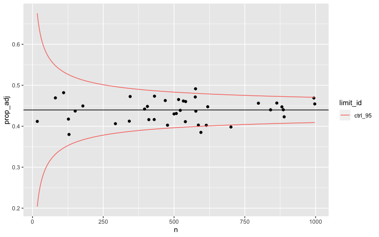

```r
# outcome ~ covariates | cluster ID
f1 <- funnel(test ~ 1 | hosp_id, data = example_data)
plot(f1)
```

The plot returned by funnelplot::plot is a standard ggplot2 object, allowing a large degree of customisation to fit the end use.

```r
pp <- plot(f1)
class(pp)
```

```
#> [1] "gg"     "ggplot"
```

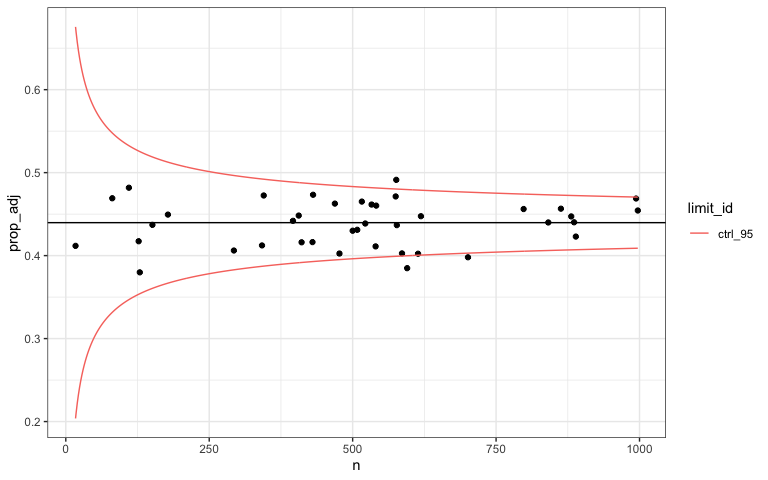

```r
pp +
  theme_bw()
```

```r
outliers(f1)
```

```
#>    id   n observed expected observed_expected  prop_obs  prop_adj
#> 15 15 595      229 261.6312         0.8752779 0.3848739 0.3848739
#> 26 26 576      283 253.2766         1.1173555 0.4913194 0.4913194
#> 39 39 701      279 308.2411         0.9051355 0.3980029 0.3980029
#>      std_err0   upper95   lower95 inside95        zz        pval
#> 15 0.02034847 0.4795986 0.3998340    FALSE -2.695159 0.007035509
#> 26 0.02068136 0.4802510 0.3991816    FALSE  2.495152 0.012590315
#> 39 0.01874698 0.4764597 0.4029729    FALSE -2.225076 0.026076105
```

### Risk adjustment

Generally raw comparison of event rates between institutions runs the risk of failing to account for differences in the populations between each cluster (e.g. a tendency for sicker patients to attend a particular hospital). To account for this a statistical model can be used to estimated hat{y} for each observation in the data - the predicted outcome given the observed covariates - which can be compared to the observed outcome y to obtain standardised rates per institution. Currently funnelplot uses logistic regression `stats::glm` for risk adjustment. A standard R formula of the form `outcome ~ covariates | clusterID` creates a risk adjusted funnel plot object.

```r
f2 <- funnel(test ~ var | hosp_id, data = example_data)
plot(f2)
```

[output not shown]

### Adjusting for multiplicity and overdispersion

```r
f3 <- funnel(test ~ var | hosp_id, data = example_data)
plot(f3)
```

[output not shown]

By default funnelplot produces risk adjusted rates, but in many circumstances standardised rates (of the form observed/expected) will be of more interest.

```r
f4 <- funnel(test ~ var | hosp_id, data = example_data)
plot(f4)
```

[output not shown]

### Plotting

Using the label and identify arguments we can label or plot only a selection of hospitals if desired. These arguments also accept “outliers” as a value.

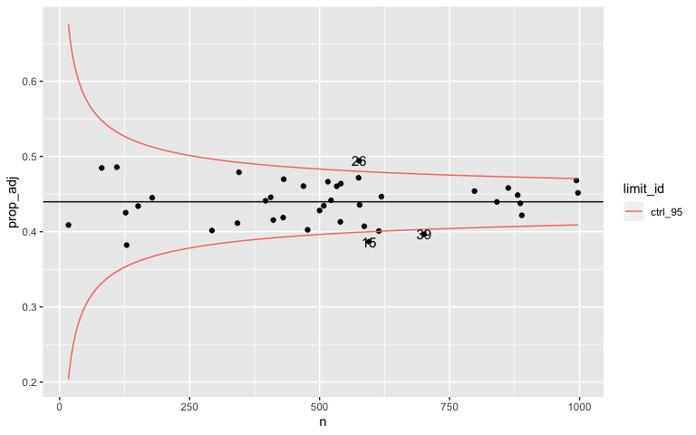

```r
plot(f4,label="outliers")
```

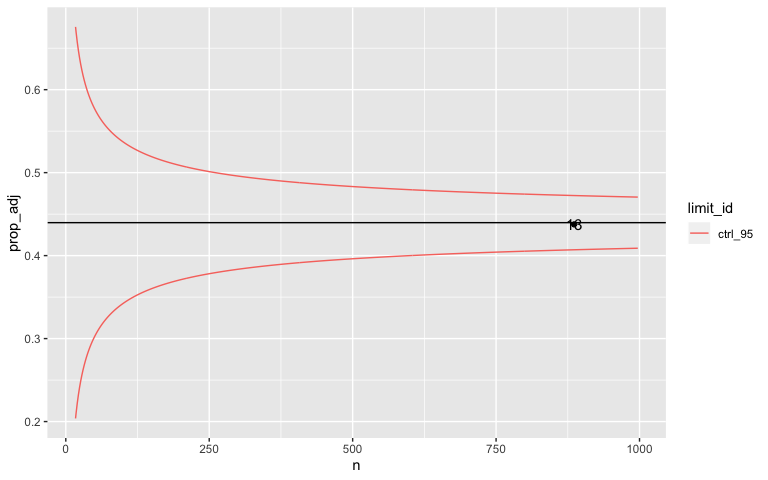

```r
plot(f4,identify=13,label=13)
```

### References

Benjamini, Y., & Hochberg, Y. (1995). Controlling the false discovery rate: a practical and powerful approach to multiple testing. Journal of the royal statistical society. Series B (Methodological), 289-300.

Jones, H. E., Ohlssen, D. I., & Spiegelhalter, D. J. (2008). Use of the false discovery rate when comparing multiple health care providers. Journal of clinical epidemiology, 61(3), 232-240.

Spiegelhalter, D. J. (2005). Funnel plots for comparing institutional performance. Statistics in medicine, 24(8), 1185-1202.